# R novice lesson

R.Lappan

20 January 2018

Material derived from Software Carpentry lesson *R novice: gapminder* http://swcarpentry.github.io/r-novice-gapminder

# Preparation

## Installation

We are going to use R and RStudio to perform exploratory analyses and make plots with a dataset containing population information for many countries through time.

Ensure you have the latest versions of R and RStudio. Just download and install them, or to update from old:

- Just download the new RStudio
- Just download the new R - reopen RStudio and it will detect it
- Copy all folders from `C:/Users/rlappan_adm/R-3.4.1/library` to `C:/Users/rlappan_adm/R-3.4.3/library` and then ran `update.packages()`

## Downloading data

Download the cats data:

```r
download.file("https://raw.githubusercontent.com/CurtinIC/cic-swc-material/master/feline-data.csv", destfile = "data/feline-data.csv")
```

And the gapminder data:

```r
download.file("https://raw.githubusercontent.com/resbaz/r-novice-gapminder-files/master/data/gapminder-FiveYearData.csv", destfile = "data/gapminder-FiveYearData.csv")
```

# A note on data frames (extremely short lesson 5)

- We have gone over the basic data types and structures in R
- We’re going to learn a little bit more about working with data frames before we move on to the real data

## Adding columns and rows in data frame

- The columns in a data frame are vectors - a series of things that are all the same type.
- So, if we want to make a new column, we can start by making a new vector (series of things)

```r
# Read in cats if you haven't already
cats <- read.csv("data/feline-data.csv")

# Create new vector for age of cats
age <- c(2, 3, 5)

# What did cats look like again?
cats
```

```
##     coat weight likes_string
## 1 calico    2.1            1
## 2  black    5.0            0
## 3  tabby    3.2            1
```

```r
# Add this vector as a new column with cbind (not overwriting the variable here)
cbind(cats, age)
```

```
##     coat weight likes_string age
## 1 calico    2.1            1   2
## 2  black    5.0            0   3
## 3  tabby    3.2            1   5
```

```r
# So let's add that column to cats - remember, you need to reassign the variable if you want it to "save" rather than just print.
cats <- cbind(cats, age)

# Cats now has a new column
cats
```

```
##     coat weight likes_string age
## 1 calico    2.1            1   2
## 2  black    5.0            0   3
## 3  tabby    3.2            1   5
```

## Adding a new row

Now, what if we want to add a new row of data? Rows can contain elements of different types, so we need to make a list.

```r
# Create a new row for a new cat
newRow <- list("tortoiseshell", 3.3, TRUE, 9)

# Add this row to the data frame with rbind
cats <- rbind(cats, newRow)
```

Remember that factors are categories, so R only allows whatever is originally there. What we have added, tortoiseshell, is ‘nonsense’ - it doesn’t fit into the categories in this column, so becomes NA.

We want to avoid something like this. There’s an important option to use when you read in files:

```r
# Read in cats again, but with new option
cats <- read.csv("data/feline-data.csv", stringsAsFactors = FALSE)

# Check out cats
str(cats)
```

```
## 'data.frame':    3 obs. of  3 variables:
##  $ coat        : chr  "calico" "black" "tabby"
##  $ weight      : num  2.1 5 3.2
##  $ likes_string: int  1 0 1
```

Now, this column has read in as a character.

We still have the newRow variable, so let’s try and add that now:

```r
# Add row
cats <- rbind(cats, newRow)

# Check cats
cats
```

[output not shown]

This now works as we thought it would.

**DO CHALLENGE ONE** - perhaps work through together to save time.

# Subsetting data: lesson 6

Let’s move a bit closer to the real world and start having a look at and playing with the gapminder data.

Read in the gapminder data:

```r
gapminder <- read.csv("data/gapminder-FiveYearData.csv")
```

What does this data look like?

```r
# Look at the whole data frame
str(gapminder)
```

```
## 'data.frame':    1704 obs. of  6 variables:
##  $ country  : Factor w/ 142 levels "Afghanistan",..: 1 1 1 1 1 1 1 1 1 1 ...
##  $ year     : int  1952 1957 1962 1967 1972 1977 1982 1987 1992 1997 ...
##  $ pop      : num  8425333 9240934 10267083 11537966 13079460 ...
##  $ continent: Factor w/ 5 levels "Africa","Americas",..: 3 3 3 3 3 3 3 3 3 3 ...
##  $ lifeExp  : num  28.8 30.3 32 34 36.1 ...
##  $ gdpPercap: num  779 821 853 836 740 ...
```

```r
# Dim for dimensions
dim(gapminder)
```

```
## [1] 1704    6
```

```r
# To see all of the columns
colnames(gapminder)
```

```
## [1] "country"   "year"      "pop"       "continent" "lifeExp"   "gdpPercap"
```

You should explore data you have read in in this way, to make sure it has read in correctly - does it look like it’s supposed to? Do the data types make sense? You can sort out problems now before you start analysing the data because otherwise you will get unexpected and wrong values down the line.

So far makes sense: let’s have a look at the data itself.

```r
# Check the first few lines
head(gapminder)
```

```
##       country year      pop continent lifeExp gdpPercap
## 1 Afghanistan 1952  8425333      Asia  28.801  779.4453
## 2 Afghanistan 1957  9240934      Asia  30.332  820.8530
## 3 Afghanistan 1962 10267083      Asia  31.997  853.1007
## 4 Afghanistan 1967 11537966      Asia  34.020  836.1971
## 5 Afghanistan 1972 13079460      Asia  36.088  739.9811
## 6 Afghanistan 1977 14880372      Asia  38.438  786.1134
```

**DO CHALLENGE TWO** - also go through this together, as we’ve skipped parts of lessons.

An important point here is that you need that comma; because the data frame has two dimensions, you need to specify which rows and columns you want to grab. If you want all rows or all columns, you leave it blank - but it still needs the comma.

How to add a column and remove a column:

```r
# Check the current columns
names(gapminder)
```

```
## [1] "country"   "year"      "pop"       "continent" "lifeExp"   "gdpPercap"
```

```r
# Add a new one
gapminder$totalgdp <- gapminder$gdpPercap * gapminder$pop

# Check
names(gapminder)
```

```
## [1] "country"   "year"      "pop"       "continent" "lifeExp"   "gdpPercap"
## [7] "totalgdp"
```

```r
# Remove it
gapminder$totalgdp <- NULL

# Check
names(gapminder)
```

```
## [1] "country"   "year"      "pop"       "continent" "lifeExp"   "gdpPercap"
```

# Data subsetting: lesson 6

So you can look at the beginning, end or middle of the data to check it out. However, if there’s a particular part of the data you are interested in - for example, all the entries from a particular country only - then we need to know a bit more about subsetting data.

## Selecting certain rows

In the challenge above we grabbed some data from the middle. What if we wanted certain rows?

```r
# Grab particular rows
gapminder[c(500, 502, 504),]
```

```
##     country year     pop continent lifeExp gdpPercap
## 500 Eritrea 1987 2915959    Africa  46.453  521.1341
## 502 Eritrea 1997 4058319    Africa  53.378  913.4708
## 504 Eritrea 2007 4906585    Africa  58.040  641.3695
```

```r
# Or multiple slices?
gapminder[c(500:505, 600:605),]
```

```
##       country year      pop continent lifeExp  gdpPercap
## 500   Eritrea 1987  2915959    Africa  46.453   521.1341
## 501   Eritrea 1992  3668440    Africa  49.991   582.8585
## 502   Eritrea 1997  4058319    Africa  53.378   913.4708
## 503   Eritrea 2002  4414865    Africa  55.240   765.3500
## 504   Eritrea 2007  4906585    Africa  58.040   641.3695
## 505  Ethiopia 1952 20860941    Africa  34.078   362.1463
## 600    Greece 2007 10706290    Europe  79.483 27538.4119
## 601 Guatemala 1952  3146381  Americas  42.023  2428.2378
## 602 Guatemala 1957  3640876  Americas  44.142  2617.1560
## 603 Guatemala 1962  4208858  Americas  46.954  2750.3644
## 604 Guatemala 1967  4690773  Americas  50.016  3242.5311
## 605 Guatemala 1972  5149581  Americas  53.738  4031.4083
```

```r
# If you ask for something outside of the data frame, you get NA
gapminder[1705,]
```

```
##    country year pop continent lifeExp gdpPercap
## NA    <NA>   NA  NA      <NA>      NA        NA
```

## Removing certain rows

Let’s take a small part of gapminder to work with. How can we remove certain elements, rather than keep?

```r
small.gapminder <- head(gapminder)

# To remove an element
small.gapminder[-2,]
```

```
##       country year      pop continent lifeExp gdpPercap
## 1 Afghanistan 1952  8425333      Asia  28.801  779.4453
## 3 Afghanistan 1962 10267083      Asia  31.997  853.1007
## 4 Afghanistan 1967 11537966      Asia  34.020  836.1971
## 5 Afghanistan 1972 13079460      Asia  36.088  739.9811
## 6 Afghanistan 1977 14880372      Asia  38.438  786.1134
```

```r
# To remove multiple elements
small.gapminder[c(-1, -5),]
```

```
##       country year      pop continent lifeExp gdpPercap
## 2 Afghanistan 1957  9240934      Asia  30.332  820.8530
## 3 Afghanistan 1962 10267083      Asia  31.997  853.1007
## 4 Afghanistan 1967 11537966      Asia  34.020  836.1971
## 6 Afghanistan 1977 14880372      Asia  38.438  786.1134
```

```r
# Alternatively
small.gapminder[-c(1, 5),]
```

```
##       country year      pop continent lifeExp gdpPercap
## 2 Afghanistan 1957  9240934      Asia  30.332  820.8530
## 3 Afghanistan 1962 10267083      Asia  31.997  853.1007
## 4 Afghanistan 1967 11537966      Asia  34.020  836.1971
## 6 Afghanistan 1977 14880372      Asia  38.438  786.1134
```

```r
# To remove a slice
small.gapminder[-(1:3),]
```

```
##       country year      pop continent lifeExp gdpPercap
## 4 Afghanistan 1967 11537966      Asia  34.020  836.1971
## 5 Afghanistan 1972 13079460      Asia  36.088  739.9811
## 6 Afghanistan 1977 14880372      Asia  38.438  786.1134
```

```r
# Remember if you actually want to remove it from the data, assign it back
small.gapminder <- small.gapminder[-4,]
```

This covers how we can select certain rows by their position, but what if we want to select certain columns?

## Selecting certain columns

```r
# Select the first to third columns
small.gapminder[,1:3]
```

```
##       country year      pop
## 1 Afghanistan 1952  8425333
## 2 Afghanistan 1957  9240934
## 3 Afghanistan 1962 10267083
## 5 Afghanistan 1972 13079460
## 6 Afghanistan 1977 14880372
```

```r
# Select the first to third by name
small.gapminder[,c("country", "year", "pop")]
```

```
##       country year      pop
## 1 Afghanistan 1952  8425333
## 2 Afghanistan 1957  9240934
## 3 Afghanistan 1962 10267083
## 5 Afghanistan 1972 13079460
## 6 Afghanistan 1977 14880372
```

```r
# Look at a single column with $
head(gapminder$gdpPercap)
```

```
## [1] 779.4453 820.8530 853.1007 836.1971 739.9811 786.1134
```

**DO CHALLENGE THREE**: Let them do this one. Put answer in the etherpad?

## Subsetting data by its features

In a large dataset, we may only be interested in certain parts of it based on the information that’s in there; for example, we might only want the data for countries in Asia, or for countries with a population of over 1 million.

Here are some ways we can subset the data based on the features we want.

```r
# Pull out the data for Australia
gapminder[gapminder$country == "Australia",]
```

```
##      country year      pop continent lifeExp gdpPercap
## 61 Australia 1952  8691212   Oceania  69.120  10039.60
## 62 Australia 1957  9712569   Oceania  70.330  10949.65
## 63 Australia 1962 10794968   Oceania  70.930  12217.23
## 64 Australia 1967 11872264   Oceania  71.100  14526.12
## 65 Australia 1972 13177000   Oceania  71.930  16788.63
## 66 Australia 1977 14074100   Oceania  73.490  18334.20
## 67 Australia 1982 15184200   Oceania  74.740  19477.01
## 68 Australia 1987 16257249   Oceania  76.320  21888.89
## 69 Australia 1992 17481977   Oceania  77.560  23424.77
## 70 Australia 1997 18565243   Oceania  78.830  26997.94
## 71 Australia 2002 19546792   Oceania  80.370  30687.75
## 72 Australia 2007 20434176   Oceania  81.235  34435.37
```

```r
# Find the data associated with Australia and Greece
gapminder[gapminder$country == "Australia" | gapminder$country == "Greece",]
```

```
##       country year      pop continent lifeExp gdpPercap
## 61  Australia 1952  8691212   Oceania  69.120 10039.596
## 62  Australia 1957  9712569   Oceania  70.330 10949.650
## 63  Australia 1962 10794968   Oceania  70.930 12217.227
## 64  Australia 1967 11872264   Oceania  71.100 14526.125
## 65  Australia 1972 13177000   Oceania  71.930 16788.629
## 66  Australia 1977 14074100   Oceania  73.490 18334.198
## 67  Australia 1982 15184200   Oceania  74.740 19477.009
## 68  Australia 1987 16257249   Oceania  76.320 21888.889
## 69  Australia 1992 17481977   Oceania  77.560 23424.767
## 70  Australia 1997 18565243   Oceania  78.830 26997.937
## 71  Australia 2002 19546792   Oceania  80.370 30687.755
## 72  Australia 2007 20434176   Oceania  81.235 34435.367
## 589    Greece 1952  7733250    Europe  65.860  3530.690
## 590    Greece 1957  8096218    Europe  67.860  4916.300
## 591    Greece 1962  8448233    Europe  69.510  6017.191
## 592    Greece 1967  8716441    Europe  71.000  8513.097
## 593    Greece 1972  8888628    Europe  72.340 12724.830
## 594    Greece 1977  9308479    Europe  73.680 14195.524
## 595    Greece 1982  9786480    Europe  75.240 15268.421
## 596    Greece 1987  9974490    Europe  76.670 16120.528
## 597    Greece 1992 10325429    Europe  77.030 17541.496
## 598    Greece 1997 10502372    Europe  77.869 18747.698
## 599    Greece 2002 10603863    Europe  78.256 22514.255
## 600    Greece 2007 10706290    Europe  79.483 27538.412
```

Note that we use OR | not AND & because none of the lines will be both Australia and Greece; we want to display the row if it is Australia, or if it is Greece.

What if you had several more things you wanted to view by? You can use %in%.

```r
# What if we want a list of countries
seAsia <- c("Myanmar", "Thailand", "Cambodia", "Vietnam", "Laos")
data.seAsia <- gapminder[gapminder$country %in% seAsia, ]

# Check out that data
dim(data.seAsia)
```

```
## [1] 48  6
```

```r
data.seAsia$country
```

```
##  [1] Cambodia Cambodia Cambodia Cambodia Cambodia Cambodia Cambodia
##  [8] Cambodia Cambodia Cambodia Cambodia Cambodia Myanmar  Myanmar
## [15] Myanmar  Myanmar  Myanmar  Myanmar  Myanmar  Myanmar  Myanmar
## [22] Myanmar  Myanmar  Myanmar  Thailand Thailand Thailand Thailand
## [29] Thailand Thailand Thailand Thailand Thailand Thailand Thailand
## [36] Thailand Vietnam  Vietnam  Vietnam  Vietnam  Vietnam  Vietnam
## [43] Vietnam  Vietnam  Vietnam  Vietnam  Vietnam  Vietnam
## 142 Levels: Afghanistan Albania Algeria Angola Argentina ... Zimbabwe
```

Okay, so what if we wanted the data for Australia but only within the past 50 years? We can specify that we want several conditions to apply when showing us the data we want.

```r
# Show me Australia data within past 50 years (later than 1968)
gapminder[gapminder$country == "Australia" & gapminder$year > 1968, ]
```

```
##      country year      pop continent lifeExp gdpPercap
## 65 Australia 1972 13177000   Oceania  71.930  16788.63
## 66 Australia 1977 14074100   Oceania  73.490  18334.20
## 67 Australia 1982 15184200   Oceania  74.740  19477.01
## 68 Australia 1987 16257249   Oceania  76.320  21888.89
## 69 Australia 1992 17481977   Oceania  77.560  23424.77
## 70 Australia 1997 18565243   Oceania  78.830  26997.94
## 71 Australia 2002 19546792   Oceania  80.370  30687.75
## 72 Australia 2007 20434176   Oceania  81.235  34435.37
```

```r
# Show me data for Australia between the years 1952 and 1972 (not inclusive)
gapminder[gapminder$country == "Australia" & gapminder$year > 1952 & gapminder$year < 1972, ]
```

```
##      country year      pop continent lifeExp gdpPercap
## 62 Australia 1957  9712569   Oceania   70.33  10949.65
## 63 Australia 1962 10794968   Oceania   70.93  12217.23
## 64 Australia 1967 11872264   Oceania   71.10  14526.12
```

```r
# The above, but inclusive
gapminder[gapminder$country == "Australia" & gapminder$year >= 1952 & gapminder$year <= 1972, ]
```

```
##      country year      pop continent lifeExp gdpPercap
## 61 Australia 1952  8691212   Oceania   69.12  10039.60
## 62 Australia 1957  9712569   Oceania   70.33  10949.65
## 63 Australia 1962 10794968   Oceania   70.93  12217.23
## 64 Australia 1967 11872264   Oceania   71.10  14526.12
## 65 Australia 1972 13177000   Oceania   71.93  16788.63
```

## Removing data by features

What if the data you want to keep is much bigger than the data you want to remove? For example, if Australia’s been collecting their data wrong and we don’t care about Australia anymore.

```r
# Remove all entries for Australia
noAust.gapminder <- gapminder[gapminder$country != "Australia",]

# Is it gone?
noAust.gapminder[noAust.gapminder$country == "Australia",]
```

```
## [1] country   year      pop       continent lifeExp   gdpPercap
## <0 rows> (or 0-length row.names)
```

```r
# Remove Australia and New Zealand
noAust.noNZ.gapminder <- gapminder[!gapminder$country %in% c("Australia", "New Zealand"),]

# Are they gone?
noAust.noNZ.gapminder[noAust.noNZ.gapminder$country %in% c("Australia", "New Zealand"),]
```

```
## [1] country   year      pop       continent lifeExp   gdpPercap
## <0 rows> (or 0-length row.names)
```

**DO CHALLENGE FOUR**

# Plotting: lesson 8

Okay let’s do something fun. Plotting your data is a great way to explore what’s in there, and the relationships between variables.

We start with the gapminder data. The data should be untouched (still 1704 obs of 6 variables) but if you accidentally changed it, just read it back in:

```r
gapminder <- read.csv("data/gapminder-FiveYearData.csv")
```

There are a few different ways to make plots in R, and today we’ll be using the ggplot2 package because it is good at creating publication-quality graphics.

When using ggplot2, we need to think of figures in layers - let’s start with an example.

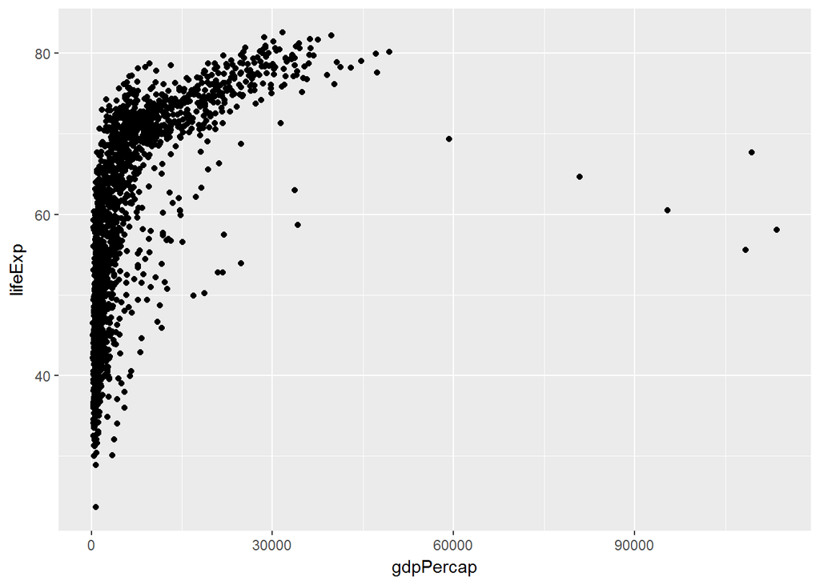

```r
# It is a separate package, we need to load it
library(ggplot2)
ggplot(data = gapminder, aes(x = gdpPercap, y = lifeExp)) +
  geom_point()
```

The plot appears in our plots window. To explain what we’ve done here, we call the ggplot function, and now we have to give ggplot the arguments. We tell it that we want to use the gapminder data with data =. With aes (aesthetics) we tell it how the variables map to the figure - so we tell it what we want on x, and what we want on y. We didn’t have to write gapminder before these because ggplot is smart enough to look in the data for the right columns.

Then, we added another line.

Notice that the call to ggplot itself isn’t enough to draw a figure:

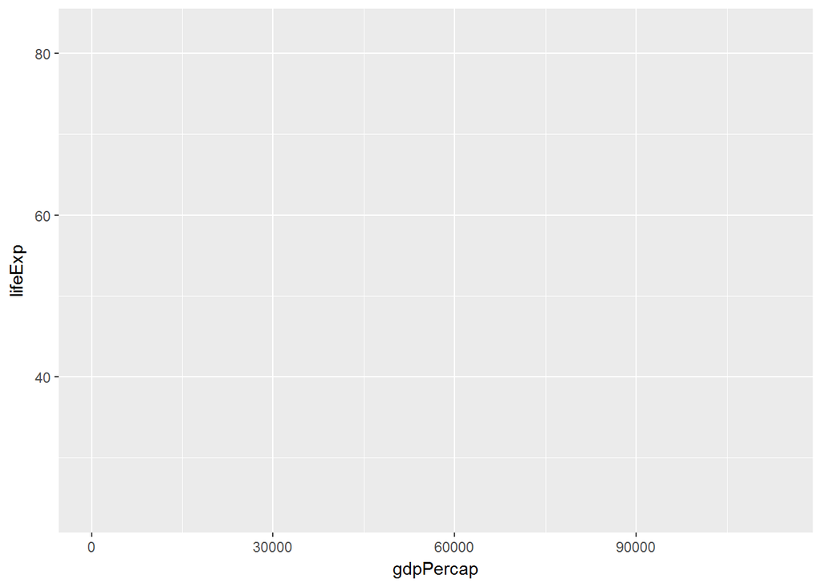

```r
ggplot(data = gapminder, aes(x = gdpPercap, y = lifeExp))
```

This tells it where things go, but not actually how to plot it. We use a new geom layer - the geom_point() function to tell ggplot that we want to plot these as a scatterplot.

**DO CHALLENGE FIVE**

The layers don’t have to be on new lines - it will still work. But it is much easier to read if they are.

## Colour

Remember that aes is aesthetics. Not only can we tell ggplot what to put on x and y, but we can tell it how to colour the points.

We can take the challenge answer for life expectancy over time, and colour the points by continent.

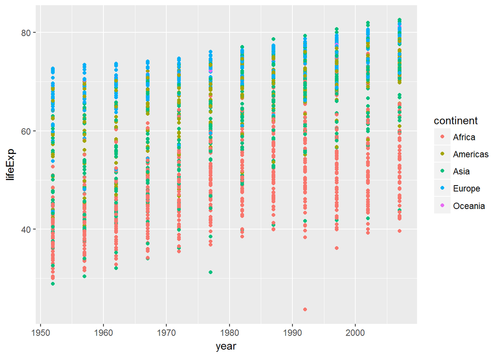

```r
# You can spell colour correctly, even though documentation uses 'color'
ggplot(data = gapminder, aes(x = year, y = lifeExp, colour = continent)) +
  geom_point()
```

## Layers

This probably isn’t the best way to display change over time, so we can use a line plot instead of a scatterplot.

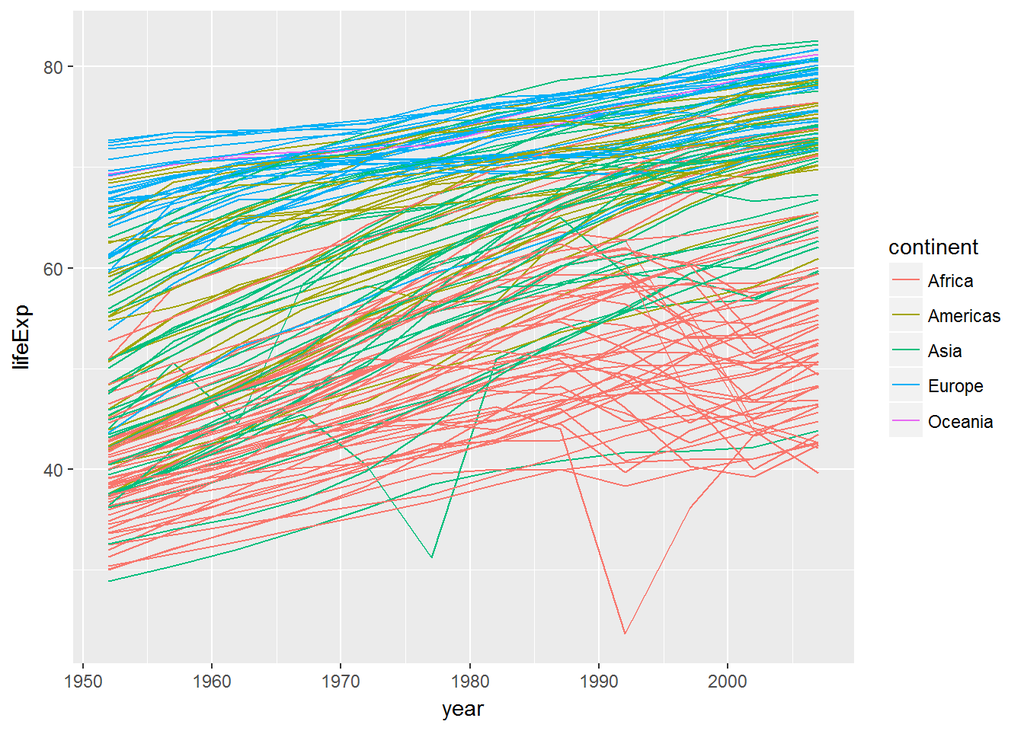

```r
ggplot(data = gapminder, aes(x = year, y = lifeExp, by = country, colour = continent)) +
  geom_line()
```

Two things have changed here - we specify a geom_line layer instead of geom_point, and we’ve added the by aesthetic, which tells ggplot to draw a line for each country.

If we want to put lines and points on the same plot, we can do so - remember, we are just adding layers.

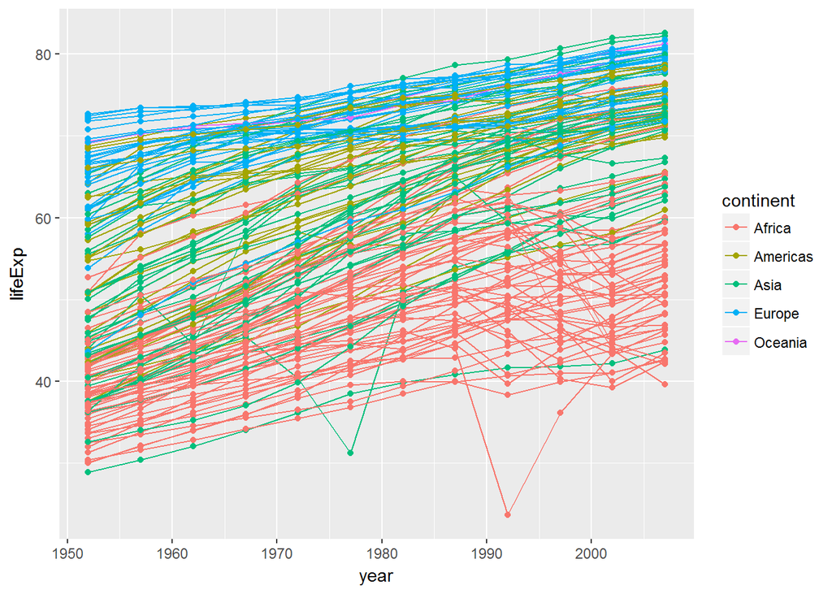

```r
ggplot(data = gapminder, aes(x = year, y = lifeExp, by = country, colour = continent)) +
  geom_line() +
  geom_point()
```

By adding more layers, each layer is drawn on top of the previous one. So here, the points are on top of the lines. We can show this by changing some colours:

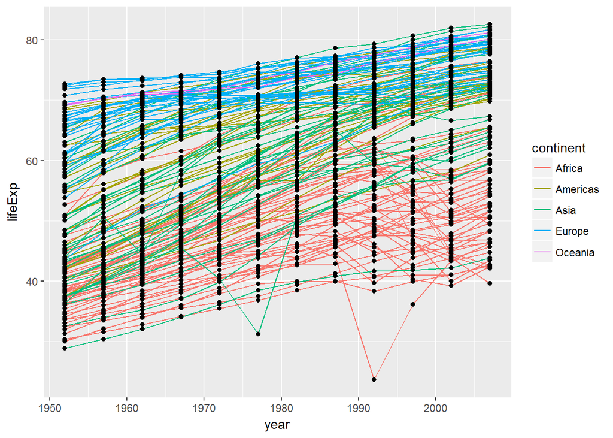

```r
ggplot(data = gapminder, aes(x = year, y = lifeExp, by = country)) +
  geom_line(aes(colour = continent)) +
  geom_point()
```

We have put the aesthetic mapping of colour onto the line layer, rather than on the overall plot - so the colour no longer applies to the points. With this we can see that the points are on top of the lines.

Note that aes() is used to map an aesthetic to a specific variable. If we wanted to make all of the lines blue, we wouldn’t use aes():

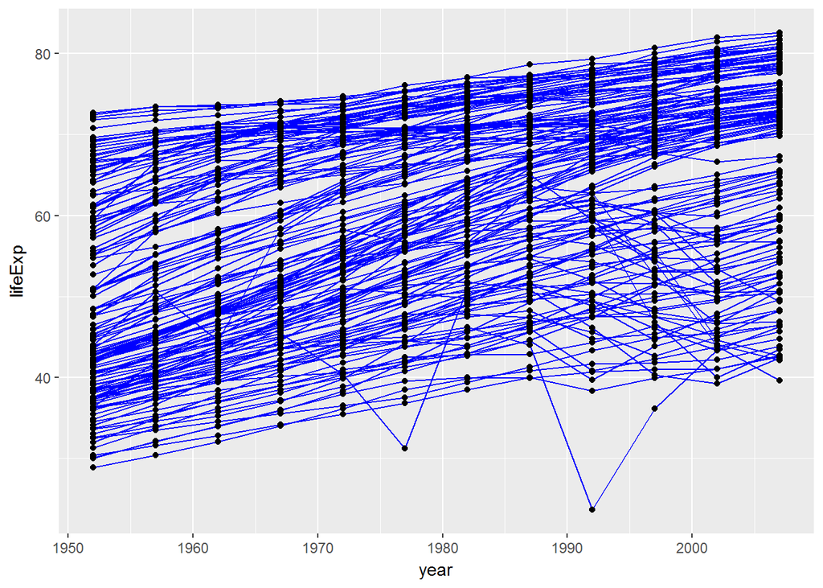

```r
ggplot(data = gapminder, aes(x = year, y = lifeExp, by = country)) +
  geom_line(colour = "blue") +
  geom_point()
```

## Transformations and statistics

ggplot also makes it easy to overlay statistical models on the data. Let’s go back to our first example with colour:

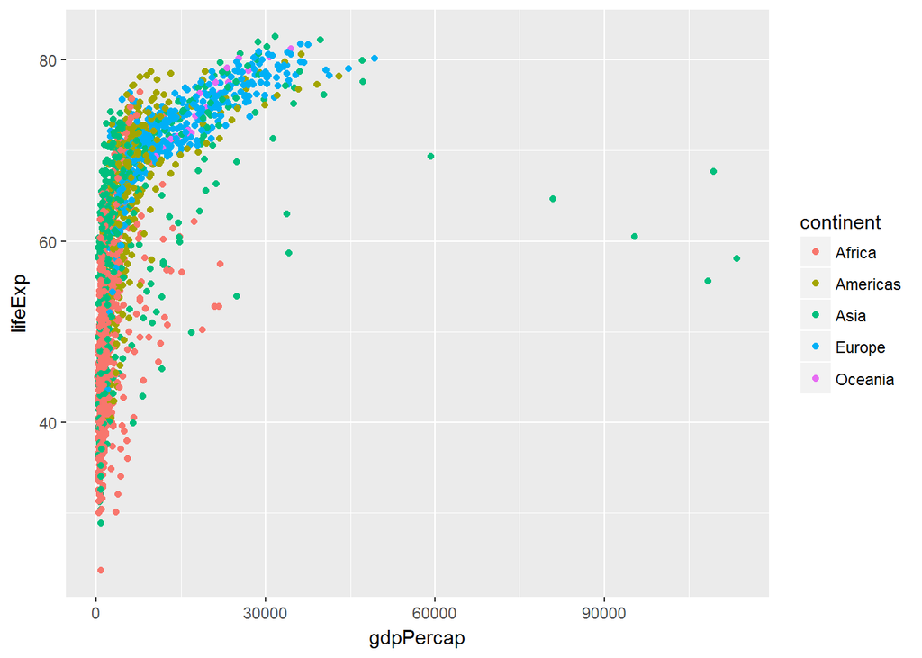

```r
ggplot(data = gapminder, aes(x = gdpPercap, y = lifeExp, color=continent)) +
  geom_point()
```

We’ve got some strong outliers, so it’s hard to see the relationship between the points. We can do a couple of things to improve this: we can change the scale of units on the x-axis, and we can modify the transparency of the points which helps if you have heavily clustered data.

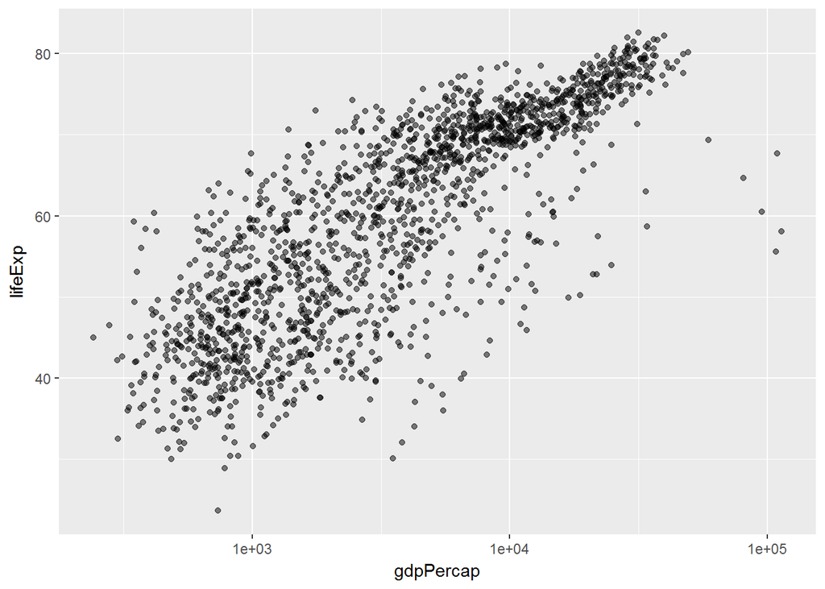

```r
ggplot(data = gapminder, aes(x = gdpPercap, y = lifeExp)) +
  geom_point(alpha = 0.5) +
  scale_x_log10()
```

The alpha function that we put within geom_point specifies the transparency of those points. The scale_x_log10 function then logs the x axis.

Remember about aesthetics and mapping - use aes() if you want to map an aesthetic to a specific variable. In this case, we wanted all of the points to be transparent, so we did it without the aes() function.

Let’s add another layer, where we fit a simple linear relationship to the plot:

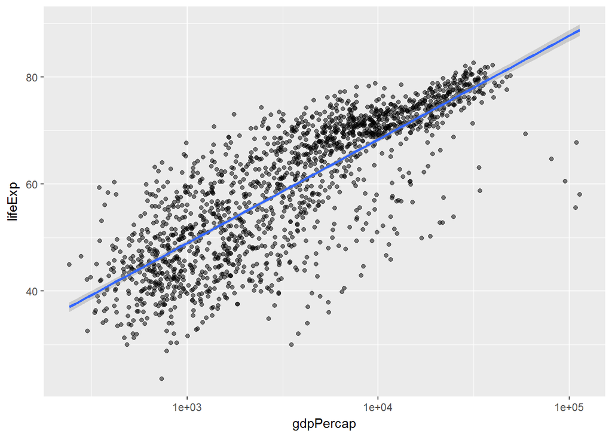

```r
ggplot(data = gapminder, aes(x = gdpPercap, y = lifeExp)) +
  geom_point(alpha = 0.5) +
  scale_x_log10() +
  geom_smooth(method = "lm")
```

This method, we are telling it which method to use to construct a linear model to fit the line.

We can make the line thicker, and let’s also give the points some colour and make them bigger:

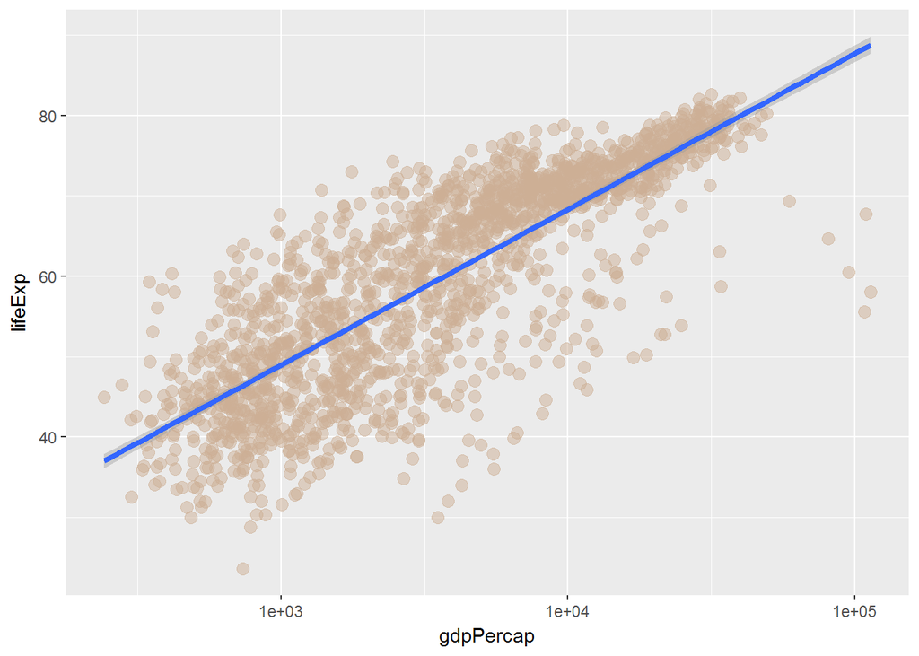

```r
ggplot(data = gapminder, aes(x = gdpPercap, y = lifeExp)) +
  geom_point(alpha = 0.5, size = 3, colour = "peachpuff3") +
  scale_x_log10() +
  geom_smooth(method = "lm", size = 1.5)
```

**DO CHALLENGE SIX**

## Multi-panel figures (skip to saving plots if short on time)

So we’ve been looking at all countiries in one plot, but we can also split this over multiple panels. Let’s look at the countries that start with the letter “A” or “Z”.

Remember what we learnt about subsetting data - we only want certain countries, but this time only the “A” or “Z” at the beginning of the country name has to match.

```r
# Let's start with a list of the first letters of all the countries
starts.with <- substr(gapminder$country, start = 1, stop = 1)
```

In this first part, we are actually subsetting the string - the series of characters - in the first column, country. We want to start at 1, then stop at 1 - so what we’re saying is we want the first letter.

You can look at starts.with with head() to see what it’s given you.

```r
# Grab the rows of gapminder that begin with A or Z
az.countries <- gapminder[starts.with %in% c("A", "Z"),]
```

What happens here - we are specifying which rows we want. We’re actually passing it some numbers of rows behind the scenes, but to instruct R which rows they are, we use this. We want the rows of starts.with that match “A” or “Z”. Because we got the starts.with vector from gapminder, the row numbers here are the same as the ones in gapminder - so those are the rows we want. This is just one way to subset the data to the things we want.

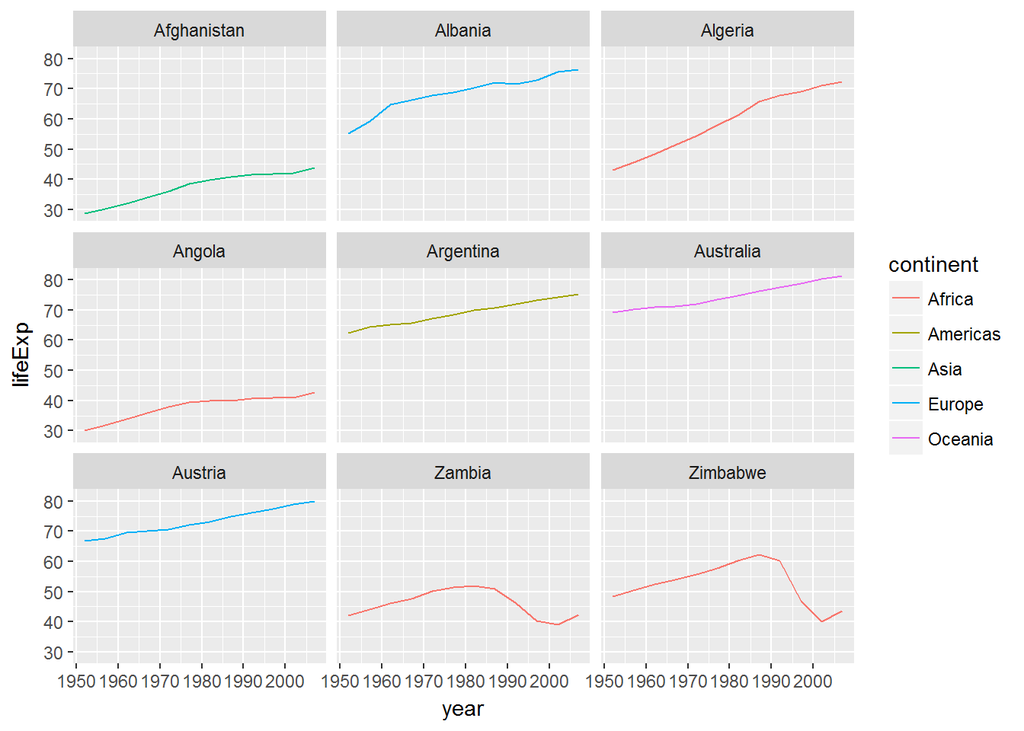

```r
# Now we can plot for just these countries, in facets
ggplot(data = az.countries, aes(x = year, y = lifeExp, colour = continent)) +
  geom_line() +
  facet_wrap("country")
```

This new facet_wrap layer tells R to draw a panel for each unique value of “country”.

## Modifying text

Now this plot looks okay, but if we were going to publish it we’d need to clean some things up - give it proper labels and make the x-axis less cluttered. We can do this by adding some more layers.

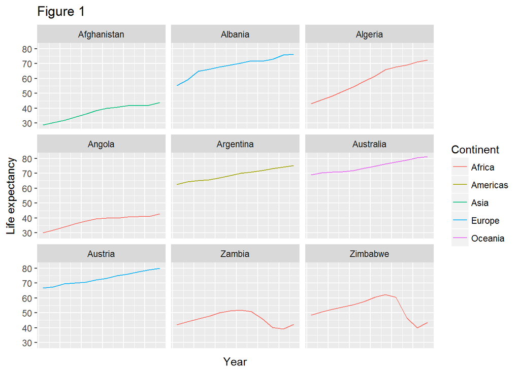

```r
ggplot(data = az.countries, aes(x = year, y = lifeExp, colour = continent)) +
  geom_line() +
  facet_wrap("country") +
  # Labs controls the labels
  labs(
    x = "Year",
    y = "Life expectancy",
    title = "Figure 1",
    # Title of the legend
    colour = "Continent"
  ) +
  # Draw nothing for the axis text and ticks on x
  theme(axis.text.x = element_blank(), axis.ticks.x = element_blank())
```

In RStudio, you can use the arrows to go back and forth between plots you’ve made.

# Saving plots - lesson 11

You’re happy with the plot and you want to save it so you can put it in your paper.

You can:

```r
# Save your most recent plot:
ggsave("most_recent_plot.pdf")
```

You can use Export from the plots window.

If you’re creating lots of plots (like several, one on each page) or you’ve got something automated that creates plots so you can’t click save after each one.

You can use pdf() to create a new pdf device - basically, turn on machine that makes pdfs, put things in it, then turn off machine (otherwise it’ll continue putting things in it).

```r
pdf("Life_Exp_vs_time.pdf", width=12, height=4)
ggplot(data=gapminder, aes(x=year, y=lifeExp, colour=country)) +
  geom_line() +
  theme(legend.position = "none")

# You then have to make sure to turn off the pdf device!

dev.off()
```

**That’s it for now - but there is so much more to learn. The Software Carpentry lesson from which this material was derived has tutorials on many other features of R:** http://swcarpentry.github.io/r-novice-gapminder